# Chapter 6: Distributions

Ram Gopal, Dan Philps, and Tillman Weyde

Summer 2022

# Multiple Distributions

We will explore distributions of two events.The first distribution we are interested in is simply tossing a coin. The second distribution is to roll a die. Let us create empirical distributions for each of these.

```r
set.seed(87654321)
coinsupport = c(0,1)
coinprob = c(.5,.5)
diesupport = seq(1,6)
dieprob = rep(1/6,6)

coinedf = sample(x = coinsupport, size = 10000, replace = T, prob = coinprob)
dieedf = sample(x = diesupport, size = 10000, replace = T, prob = dieprob)
```

Now that we have created these distributions empirically, let us take a look at the empirical probabilities.

```r
prop.table(table(coinedf))
```

```
## coinedf
##      0      1
## 0.5082 0.4918
```

```r
prop.table(table(dieedf))
```

```
## dieedf
##      1      2      3      4      5      6
## 0.1623 0.1654 0.1676 0.1650 0.1686 0.1711
```

Suppose we are interested in the following probabilities: the probability of getting a head, and the probability of rolling a 4. Based on the empirical probabilities, we can write:
$$P(coin = heads)= 0.4918$$
$$P(die = 4)=0.1650$$

Suppose the event we are interested in is the following: **we toss a coin first, and subsequently, we will roll a die**.

What is the probability that we get a heads and a roll of 4? We can compute this empirically.

```r
prop.table(table(coinedf,dieedf))
```

```
##        dieedf
## coinedf      1      2      3      4      5      6
##       0 0.0818 0.0812 0.0860 0.0875 0.0876 0.0841
##       1 0.0805 0.0842 0.0816 0.0775 0.0810 0.0870
```

From the above distribution, we can see that:
$$P(coin = head \text{ and } die = 4)=
0.0775$$

This is called the **joint probability** of heads and 4. How is this related to the individual probabilities of heads and 4? If the two events A and B are independent, we have
$$P(A \text{ and } B) = P(A) \times
P(B)$$

In our case, $P(coin = heads) = 0.4918$ and $P(die = 4) = 0.1650$.

```r
0.4918 * 0.1650
```

```
## [1] 0.08115
```

These are fairly close given the magnitude of the data, indicating that these two events are independent. This makes sense, because flipping a coin has nothing to do with rolling a die. In other words, the outcome of one should not have any impact on the outcome of the other.

Now, let us consider another example. Read the file called **Transactions** (you can download this file from the link at the bottom of the page). The data set contains transactions of consumers. 0 indicates the item was not purchased, and 1 indicates it was purchased.

```r
Transactions <- read.csv("../../data/Transactions.csv", stringsAsFactors=TRUE)
knitr::kable(Transactions[1:5,])
```

| Transaction | Bow | Candy.Bar | Deodorant | Greeting.Cards | Magazine | Markers | Pain.Reliever | Pencils | Pens | Perfume | Photo.Processing | Prescription.Med | Shampoo | Soap | Toothbrush | Toothpaste | Wrapping.Paper |
| --- | --- | --- | --- | --- | --- | --- | --- | --- | --- | --- | --- | --- | --- | --- | --- | --- | --- |
| 1000004 | 0 | 0 | 0 | 0 | 0 | 0 | 0 | 1 | 0 | 0 | 0 | 0 | 0 | 0 | 0 | 0 | 0 |
| 1000007 | 0 | 0 | 0 | 0 | 0 | 0 | 0 | 0 | 0 | 0 | 0 | 0 | 0 | 1 | 0 | 0 | 0 |
| 100001 | 0 | 1 | 0 | 0 | 0 | 0 | 0 | 0 | 0 | 0 | 0 | 0 | 0 | 0 | 0 | 0 | 0 |
| 1000010 | 0 | 0 | 0 | 0 | 0 | 0 | 0 | 0 | 1 | 0 | 0 | 0 | 0 | 0 | 0 | 0 | 0 |
| 1000016 | 0 | 0 | 0 | 1 | 0 | 0 | 0 | 0 | 0 | 0 | 0 | 0 | 0 | 0 | 0 | 0 | 0 |

We are interested in two items: toothbrush and perfume. Let us compute the individual and joint probabilities of these two items.

```r
prop.table(table(Transactions$Toothbrush))
```

```
##
##       0       1
## 0.92785 0.07215
```

```r
prop.table(table(Transactions$Perfume))
```

```
##
##       0       1
## 0.90682 0.09318
```

```r
prop.table(table(Transactions$Toothbrush, Transactions$Perfume))
```

```
##
##           0       1
##   0 0.85791 0.06994
##   1 0.04891 0.02324
```

We have `P(Toothbrush) = 0.07215` and `P(Perfume) = 0.09318`, and the joint probability is `P(Toothbrush AND Perfume) = 0.02324`.

```r
.0721 * .09318
```

```
## [1] 0.006718
```

As you can see, `P(Toothbrush AND Perfume)` is significantly bigger than `P(Toothbrush) X P(Perfume)`. This means the purchase of a toothbrush and perfume are not independent. We define the measure called **lift**. which is
$$Lift = \frac{P(A \text{ and } B)}{P(A) \times
P(B)}$$

In our case,

```r
lift = 0.02324487/(.0721 * .09318)
lift
```

```
## [1] 3.46
```

the lift value of 3.46 indicates there is a strong association between the purchase of these two items. The probability that the consumer would buy these two together is 3.46 times more than if it were to occur randomly.

# Univariate and Multivariate Distributions

All the univariate distributions we have discussed thus far, including normal, Poisson, exponential, have corresponding multivariate distributions.

For example, the pdf for a multivariate normal distribution is the following:

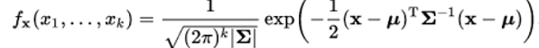

The mean and the variance are described in matrix forms. For example, a bivariate normal distribution is specified as:

$$N
\left(\begin{bmatrix}
\mu_1 \\
\mu_2\\
\end{bmatrix}
,
\begin{bmatrix}
\sigma_1^2 & \sigma_{12}^2\\
\sigma_{12}^2 & \sigma_2^2 \\
\end{bmatrix} \right)$$

where $\sigma_{12}^2$ is the covariance between the two variables.

Let us create some random data from the following bivariate normal distribution using the package $mvtnorm$.

$$N
\left(\begin{bmatrix}
4 \\
10\\
\end{bmatrix}
,
\begin{bmatrix}
2 & 1\\
1 & 3 \\
\end{bmatrix} \right)$$

Let us create ten random values.

```r
library(mvtnorm)
M = c(4,10)
S = matrix(c(2,1,1,3), nrow = 2, ncol = 2)
x = rmvnorm(10,mean = M,sigma = S)
x
```

```
##        [,1]   [,2]
##  [1,] 5.356 11.276
##  [2,] 2.960  9.309
##  [3,] 4.749  8.530
##  [4,] 3.366 11.061
##  [5,] 4.113 12.283
##  [6,] 4.838  9.093
##  [7,] 3.710  8.047
##  [8,] 0.524  8.165
##  [9,] 3.821  9.248
## [10,] 6.563 10.172
```

The correlation between the two in the sample is

```r
cor(x[,1],x[,2])
```

```
## [1] 0.371
```

Now let us plot this bivariate distribution. The `MASS` package has a function called `kde2d()` to create the density values, which can then be plotted with `persp()`. The two parameters `theta` and `phi` are used to specify the viewing angle.

First, we will create 1000 random values from the bivariate distribution, and then plot the density of it.

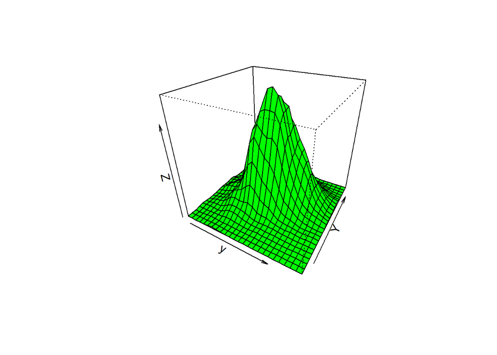

```r
library(MASS)
x = rmvnorm(1000,mean = M,sigma = S)
y = kde2d(x = x[,1], y = x[,2])
persp(y, col="green",theta = 30, phi = 30)
```

# Transformations and Convolutions

Let us empirically create a uniform distribution.

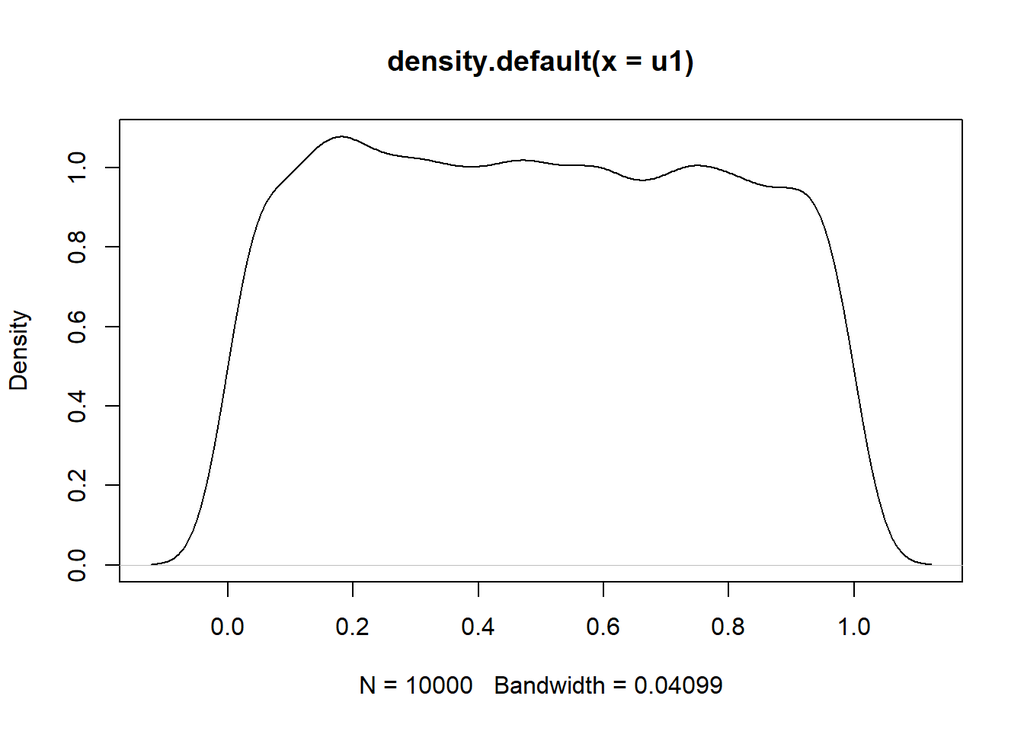

```r
u1 = runif(10000)
plot(density(u1))
```

What if we square the random numbers? Will the resulting distribution still be uniform?

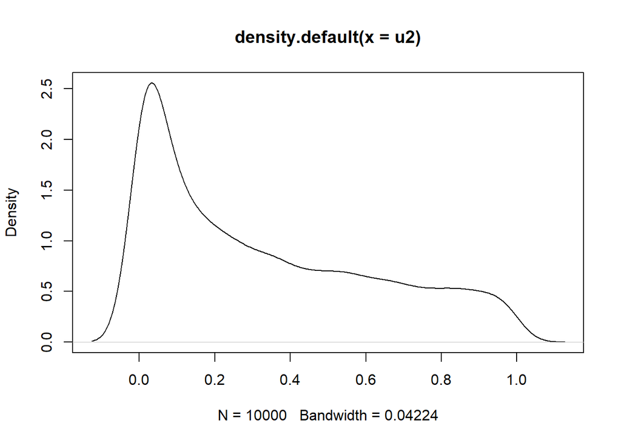

```r
u2 = u1^2
plot(density(u2))
```

What if we take the square root?

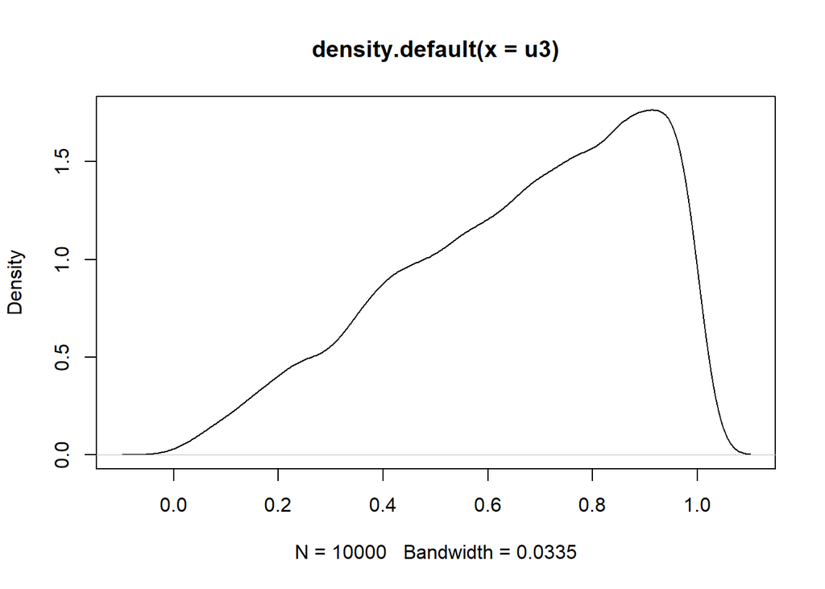

```r
u3 = sqrt(u1)
plot(density(u3))
```

Once you transform a uniform random variable, it is no longer uniform.

Let us take the exponential of a normal distribution.

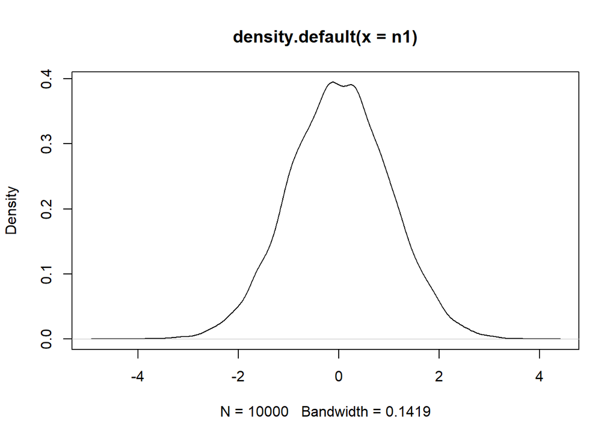

```r
n1 = rnorm(10000)
plot(density(n1))
```

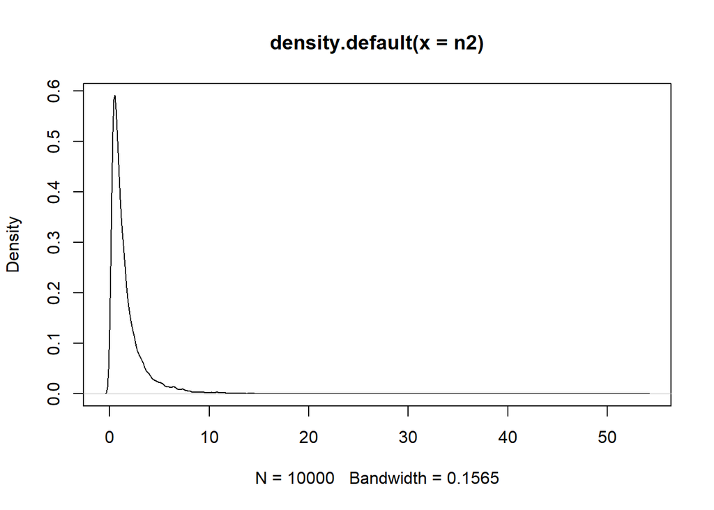

```r
n2 = exp(n1)
plot(density(n2))
```

Taking the exponential of random normal variable changes the domain (to $[0,\infty]$) and induces a right skew. This, in fact, is called a **lognormal** distribution. This is used to capture variables like income, which can only be positive, and often exhibits a right skew. Most people have lower incomes, with a few very rich people who create the skew in the income distribution.

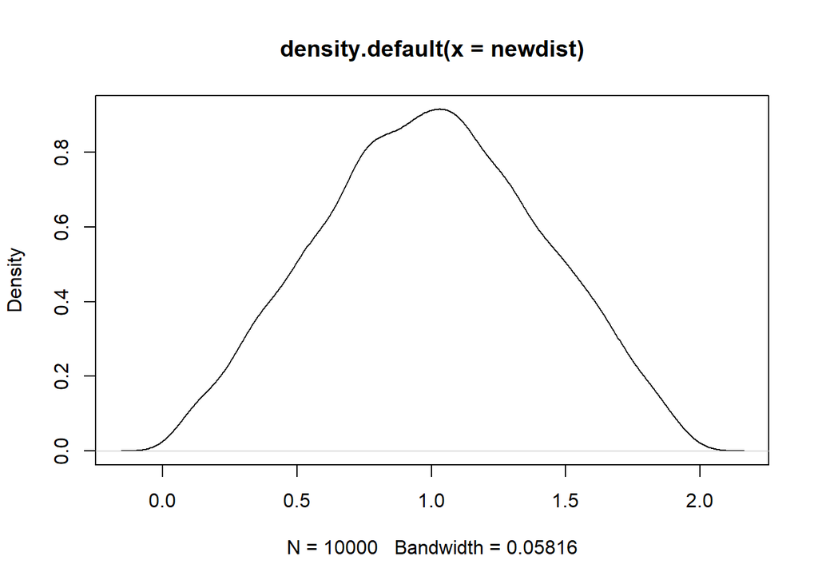

```r
u4 = runif(10000)
u5 = runif(10000)
newdist = u4 + u5
plot(density(newdist))
```

Now let us add 3 more uniform distributions and 2 normal distributions to this.

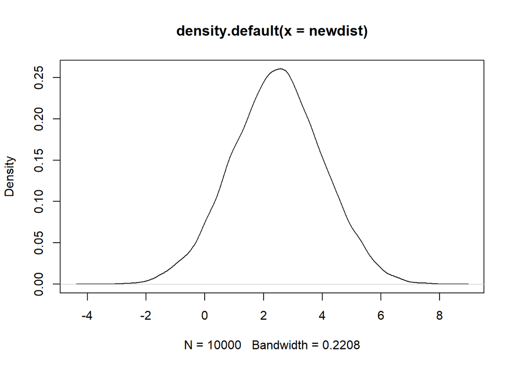

```r
u6 = runif(10000)
u7 = runif(10000)
u8 = runif(10000)
e1 = rnorm(10000)
e2 = rnorm(10000)
newdist = newdist + u6 + u7 + u8 + e1 + e2
plot(density(newdist))
```

The result looks to be a normal distribution. This is a very important insight from the central limit theorem.

# Sampling Distributions

The last topic that we will address here is sampling distributions. Sampling distributions are important to conduct statistical testing. Let us explore this.

There is a data frame called `women`. Let us take a look at this.

```r
knitr::kable(women)
```

| height | weight |
| --- | --- |
| 58 | 115 |
| 59 | 117 |
| 60 | 120 |
| 61 | 123 |
| 62 | 126 |
| 63 | 129 |
| 64 | 132 |
| 65 | 135 |
| 66 | 139 |
| 67 | 142 |
| 68 | 146 |
| 69 | 150 |
| 70 | 154 |
| 71 | 159 |
| 72 | 164 |

Let us assume that the `weight` of the women in the data frame constitutes the **entire population** of interest for us. Let us calculate the population mean and standard deviation.

```r
popmean = mean(women$weight)
popsd = sd(women$weight)
paste("population mean = ", popmean)
```

```
## [1] "population mean =  136.733333333333"
```

```r
paste("population standard deviation = ", popsd)
```

```
## [1] "population standard deviation =  15.4986942614378"
```

Suppose we want to do the following: from this population, we want to draw a sample of size 5. This is illustrated in the figure below.

[figure not shown]

The code is

```r
set.seed(87654321)
s = sample(x = women$weight, size = 5, replace = F)
paste("sample mean = ", mean(s))
```

```
## [1] "sample mean =  134.4"
```

The sample mean is a bit different from the true population mean. A question that comes up naturally is how close or how far the sample mean can be from the true population mean.

To get an idea, let us replicate this process of drawing a sample and computing the sample mean 10000 times. This is illustrated in the figure below.

[figure not shown]

```r
f1 = function(){
  s = sample(x = women$weight, size = 5, replace = F)
  return(mean(s))
}
samplingdist = replicate(10000, f1())
```

Now let us find out how small or how large the mean can be from a sample.

```r
paste("smallest sample mean = ", min(samplingdist))
```

```
## [1] "smallest sample mean =  120.2"
```

```r
paste("largest sample mean = ", max(samplingdist))
```

```
## [1] "largest sample mean =  154.6"
```

What if you take the mean of this distribution?

```r
paste("mean of the sampling distribution = ", mean(samplingdist))
```

```
## [1] "mean of the sampling distribution =  136.72634"
```

It is very close to the true population mean!

This is called the **sampling distribution**. Let us plot the sampling distribution.

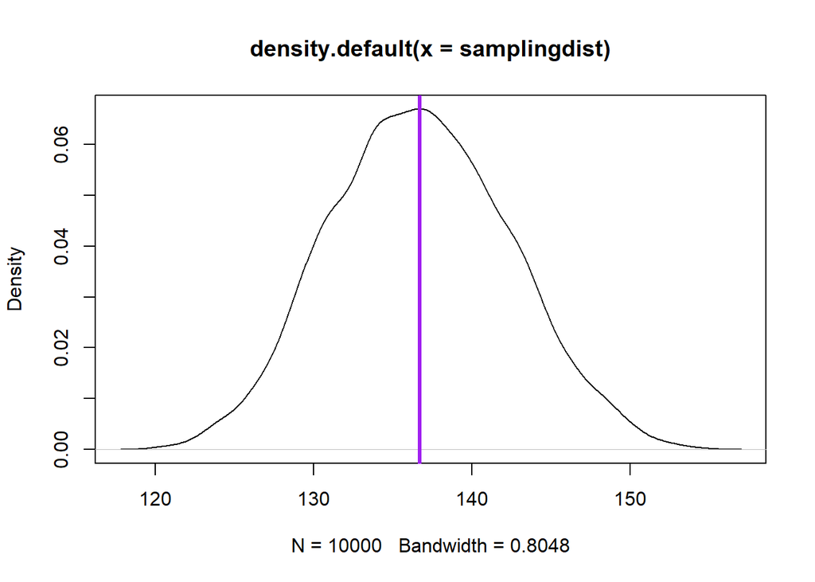

```r
plot(density(samplingdist))
abline(v = mean(samplingdist), col = "purple", lwd = 3)
```

Note that `lwd` specifies the line width. You will notice that the sampling distribution looks normal.

The characteristics of the sampling distribution are described by the famous central limit theorem. Central limit theorem, in essence, states that if you take any population distribution and start drawing many samples from it, the distribution of the means from each of the samples follows a normal distribution. Thus, it describes the nature of the sampling distribution. In addition, it states that the standard deviation of the sampling distribution is (standard deviation of the population divided by the square root of the sample size). The sampling distribution of the sample mean becomes almost normal regardless of the shape of the original population from which we created the sampling distribution.

This time, we will recreate this with the median of the sample as our statistic of interest.

```r
f2 = function(){
  s2 = sample(x = women$weight, size = 5, replace = F)
  return(median(s2))
}
samplingdist2 = replicate(10000, f2())
```

Let us calculate the population median.

```r
paste("popluation median = ", median(women$weight))
```

```
## [1] "popluation median =  135"
```

```r
paste("mean of the sampling distribution = ", mean(samplingdist2))
```

```
## [1] "mean of the sampling distribution =  135.5419"
```

Very close! Let us plot this.

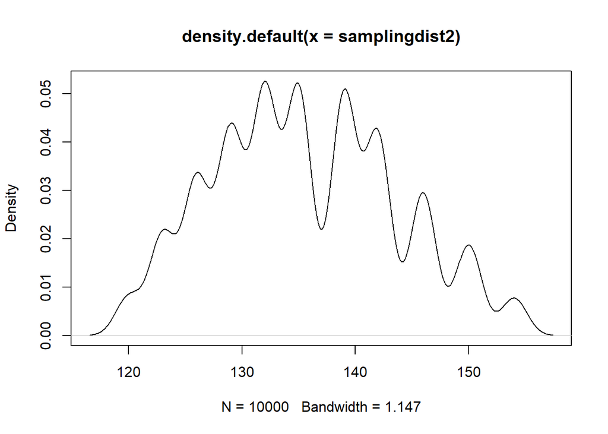

```r
plot(density(samplingdist2))
```

This is not really normal. Thus, the shape of the sampling distribution is normal only if our statistic of interest is the mean. No guarantees for other statistics of interest.

Here is another example. Let us try to create the sampling distribution out of the following population distribution.

| Value | Probability |
| --- | --- |
| 1 | .5 |
| 4 | .1 |
| 15 | .1 |
| 72 | .3 |

Let us create a sampling distribution of the mean when we draw samples from the above distribution of size = 100.

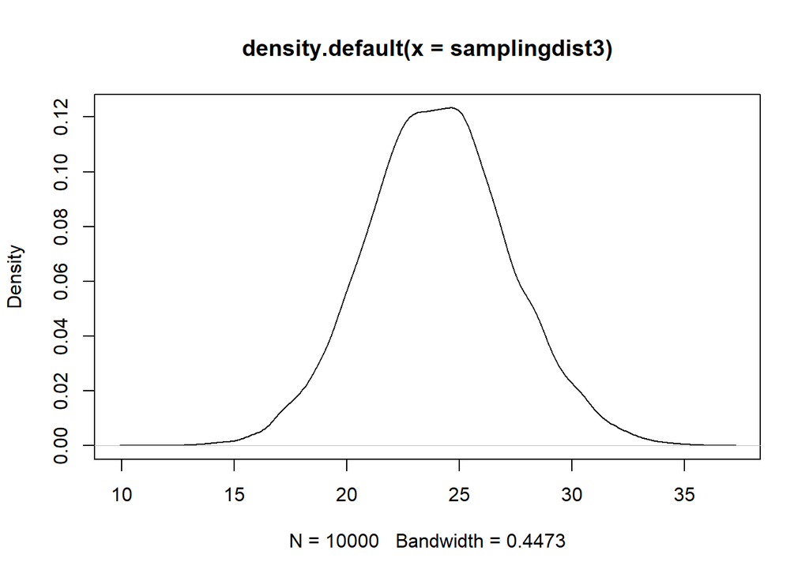

```r
v = c(1,4,15,72)
p = c(.5,.1,.1,.3)
f3 = function(){
  s3 = sample(x = v, size = 100, replace = T, prob = p)
  return(mean(s3))
}
samplingdist3 = replicate(10000, f3())
plot(density(samplingdist3))
```

This looks very normal!

Now, let us do this with standard deviation as the statistic of interest.

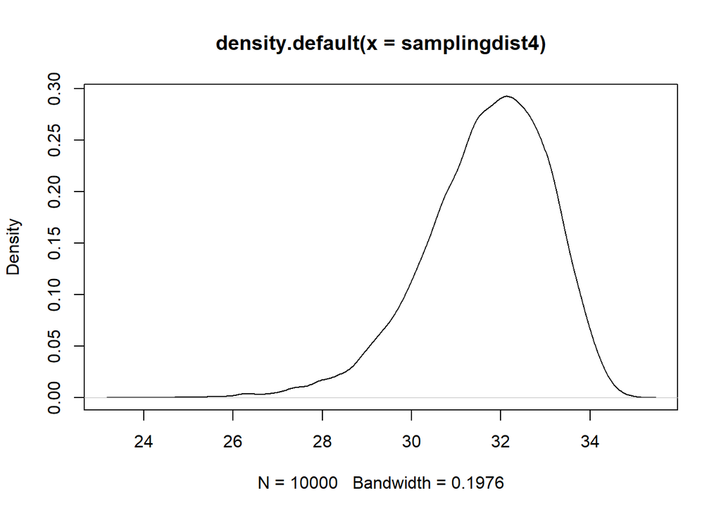

```r
v = c(1,4,15,72)
p = c(.5,.1,.1,.3)
f4 = function(){
  s4 = sample(x = v, size = 100, replace = T, prob = p)
  return(sd(s4))
}
samplingdist4 = replicate(10000, f4())
plot(density(samplingdist4))
```

When we changed the statistic from the mean to the standard deviation, the sampling distribution is no longer normal. Now, let us try median as the statistic of interest.

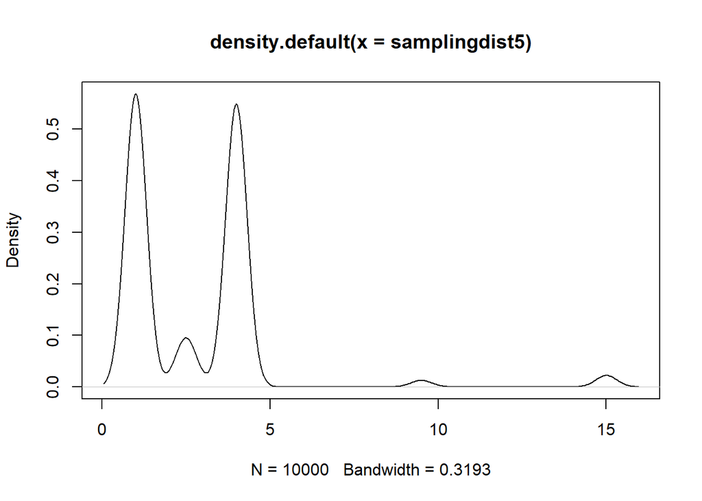

```r
v = c(1,4,15,72)
p = c(.5,.1,.1,.3)
f5 = function(){
  s5 = sample(x = v, size = 100, replace = T, prob = p)
  return(median(s5))
}
samplingdist5 = replicate(10000, f5())
plot(density(samplingdist5))
```

Definitely not normal!

The takeaway from this is that the only statistic which will create a normal sampling distribution is the mean. Other statistics may create distributions that look far from normal.

Sampling distributions form the foundation of how we conduct statistical testing. We will explore this in detail in the next lesson. For now, the important thing to remember is that, before you can create a sampling distribution, you first need to describe your population. After that, you decide the **sample size** and the **statistic** you are interested in. Once you identify these, you can easily create the sampling distribution.

# Files to Download

[Transactions.csv file](https://drive.google.com/file/d/18KzQxvyb2Rql-IKtnJFGJCIGDZOEji9q/view?usp=sharing)